# Module 9 Lecture - Lifespan Development

Introductory Psychology

Quinton Quagliano, M.S., C.S.P

Department of Psychology

# 1 Overview and Introduction

Agenda

1 Overview and Introduction

2 What is Lifespan Development?

3 Lifespan Theories

4 Conclusion

## 1.1 Textbook Learning Objectives

- Define and distinguish between the three domains of development: physical, cognitive and psychosocial
- Discuss the normative approach to development
- Understand the three major issues in development: continuity and discontinuity, one common course of development or many unique courses of development, and nature versus nurture
- Discuss Freud’s theory of psychosexual development
- Describe the major tasks of child and adult psychosocial development according to Erikson
- Discuss Piaget’s view of cognitive development and apply the stages to understanding childhood cognition
- Describe Kohlberg’s theory of moral development
- Compare and contrast the strengths and weaknesses of major developmental theories

## 1.2 Instructor Learning Objectives

- Be able to identify key characteristics and ideas from the different developmental theories
- Be able to connect the different theorists to their views and perspectives
- Be able to apply the different developmental stages, given a specific age in an example

## 1.3 Introduction

- In this module, we will focus on the different perspectives of development of humans
  - There have been many different theories and ideas that describe how and why we develop, and it’s important you can identify which people proposed which ideas
- **Important: Much like with other theories we have discussed, there is not one fully 'correct' option; we should understand these different theories as offering different, and at times, complimentary information on our development.**

# 2 What is Lifespan Development?

Agenda

1 Overview and Introduction

2 What is Lifespan Development?

3 Lifespan Theories

4 Conclusion

## 2.1 Introduction

- While **developmental psychologist** are often associated with research on children, many actually research across the lifespan
- What is the **lifespan**?
  - It contains every stage of life, from conception to death
  - Across each of these stages, we look at three areas:
    - Physical development
    - Cognitive development
    - Psychosocial development
- **Discuss: If we are in a psychology class, why would we care about physical development?**

## 2.2 Different Areas of Development

- The focus of **physical development** is on the anatomical and physiological changes to the body
  - E.g., changing hormones during puberty, developing control over speech muscles
- On the other hand, **cognitive development** focuses on things that we covered in module 7: like how we solve problems
  - E.g., development of better concentration, and faster processing speed
- Finally, **psychosocial development** is all about how people socialize with one another and how we portray our personality and emotions
  - E.g., developing inhibition against anger and sadness, like less tantrums (ideally)
- **Discuss: What is *one* way that you have developed as a person from middle school to college? I.e., describe one of your characters arcs. Which of the above areas would this fall under?**

## 2.3 The Normative Approach to Developmental Psychology

- Much of developmental psychology is interested in what is the normal or the “usual” healthy course of development, especially early in life
  - This is still a focus today, but many clinicians stay away from describing children or development as “normal” or “abnormal”
  - This approach to research is called the **normative approach**
- **Important: Many terms that started as scientific have been used as insults, e.g., 'retarded' just means 'slow', but has been used harmfully against many children. Be mindful of how clinical terms may be stigmatizing.**
- Having some sense of typical development can be useful in defining **developmental milestones**, distinct stages in our development
  - E.g., Crawling, Walking, first words, speaking and sentences
- While more biological milestones, like puberty, tend to be universal and occur at roughly the same time across different cultures, social milestones may be vastly different in different populations
  - E.g., First formal schooling may be very different in different countries
- **Discuss: Why might a normative approach to developmental psychology might be anxiety inducing in a parent of a young child?**

## 2.4 Nuances in Developmental Psychology

- As we work through the following theories and researchers, keep in mind these several differences in how development is viewed:

### Continuous or Discontinuous?

- The view of **continuous development** is that development is a steadily and gradually increasing slope
  - E.g., Slowly increasing height, weight throughout childhood
- Alternatively, **discontinuous development** is that which is organized into discrete stages
  - E.g., Pre-walking to Post-walking

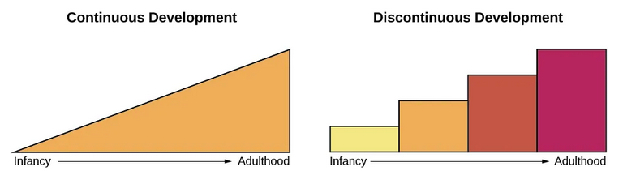

- **Question: I am looking at the timing of when a child first becomes capable of recognizing themself in the mirror, and from this point on, they now recongize themself in reflection - is this better showing continuous or discontinuous development?**
- A) Continuous
- B) Discontinuous
- C) Neither
- D) Both
- **Important: You don't necessarily need to believe development is entirely continuous or entirely discontinuous! Maybe different components progress differently...**

### One Course or Many?

- Does our development course differ based upon our culture, society, and environment? Or it is generally universal regardless of our culture?
- **Discuss: If we do differ across cultures, how might this make the normative approach to development more complicated?**

### Nature or Nurture (or Both)?

- **Discuss: During what previous topic did we talk about nature and nurture (very briefly!)**
- Our **nature** is our innate, built-in characteristics
  - E.g., our skin tone, our potential height, our facial structure
- But with **nurture**, we have how our environment shapes our development
  - E.g., whether we are raised in a certain religion, certain political beliefs, certain ethical beliefs
- **Important: Like with pretty much everything we talk about in psychology - it's complicated - rarely is any part of how we think, act, and behave purely ascribable to our nature or nurture**

# 3 Lifespan Theories

Agenda

1 Overview and Introduction

2 What is Lifespan Development?

3 Lifespan Theories

4 Conclusion

## 3.1 Psychosexual Theory of Development (Frued)

- The OG (for better or for worse); Sigmund Freud’s theories on unconscious behaviors and tendencies were among the first theories of child development
- **Question: Which historical perspective is Freud associated with?**
- A) Evolutionary
- B) Biopsychology
- C) Psychoanalysis
- D) Cognitivism
- His focus was on the **psychosexual theory of development** which focused primarily on how stages and fixations towards certain erogenous zones and pleasure seeking in each one of those zones
  - These zones are: oral, anal, phallic, latency, and genital
  - Importantly, Freud placed *a lot* of emphasis on childhood as the time where development takes place, rather than throughout the lifespan
- In recent years, Freud’s ideas have been less empirically validated than other theories
  - But the guy was right every once in awhile…
- **Important: Even though Freud's exact stages and explanations have fallen out of favor, he was one of the earliest voices to point to the importance of childhood development in later life outcomes - without him, we may have not had the other theorists that come up in these next sections.**

## 3.2 Psychosocial Theory of Development (Erikson)

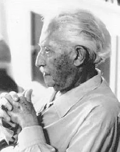

- Erik Erikson was the primary theorist to develop **psychosocial theory of development**, which focused less on the sexual, and more on the social (duh)
  - More specifically, we pursue different types of social competence in certain areas at several stages throughout our entire lifespan
  - Each stage of psychosocial development has a task or tension between a negative and a positive outcome, which will have downstream effects on our development

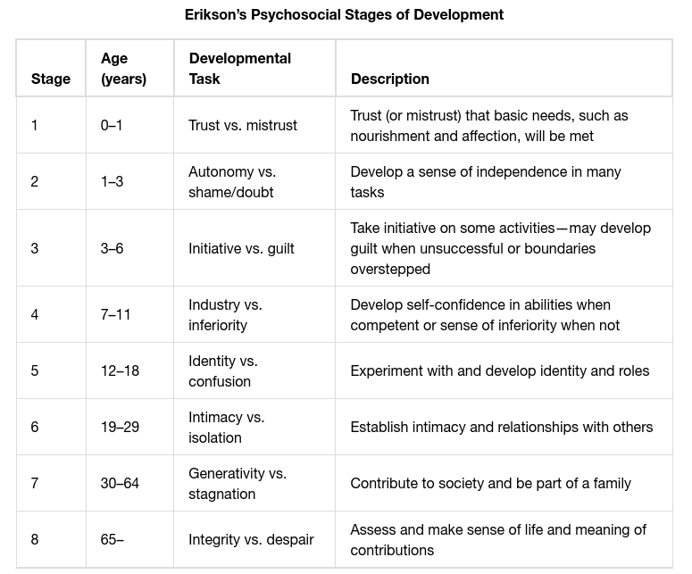

- **Discuss: Based on the brief descriptions of both, how are the psychosexual and psychosocial theories different and similar from one another?**
- **Important: One of the things that makes Erikson's theory unique is that it does put special emphasis on the entire lifespan, not just childhood**

## 3.3 Cognitive Theory of Development (Piaget)

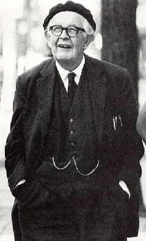

- Contrasting with the Psychosexual and Psychosocial, Jean Piaget formulated a developmental theory as being connected to distinct cognitive stages, through the **cognitive theory of development**
  - Piaget’s theory of development was very strongly connected to the growing cognitive abilities of children as they matured.
- Piaget’s ideas of cognitive development focused on how children produce schemata to help them categorize their world
  - Within these schemata, children **assimilate** new concepts into existing schemata
  - They also begin to **accommodate** challenging information
- **Discuss: What is the difference between a schema and a concept?**

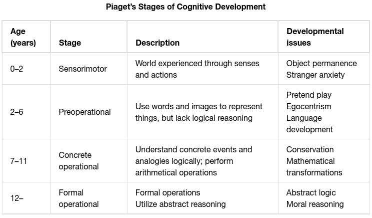

## 3.4 Moral Theory of Development (Kohlberg)

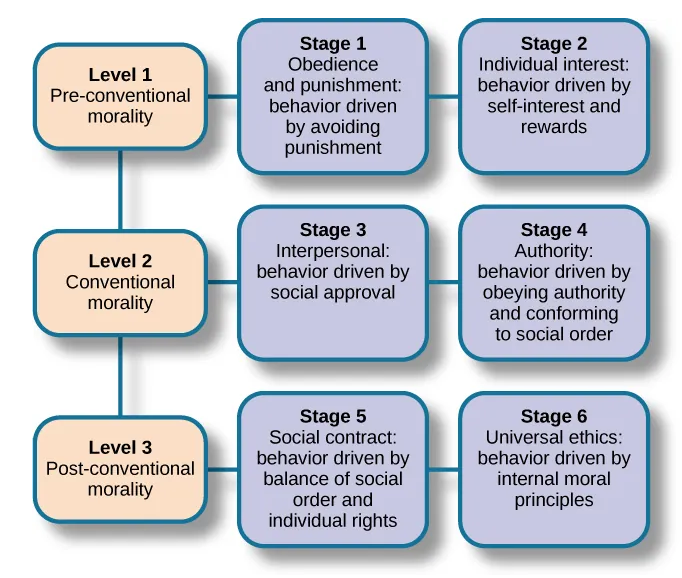

# 4 Conclusion

Agenda

1 Overview and Introduction

2 What is Lifespan Development?

3 Lifespan Theories

4 Conclusion

## 4.1 Recap

- Developmental psychology is not just about childhood, but about our entire lifespan. This includes how adulthood is influenced by our childhood, but also how we keep growing and evolving even once we are adults
- We can understand development sexually, socially, cognitive, and morally through the different theorists models of our growth and development - each of these models have their own stages related to different behaviors and goals
- Each model has its own set of unique vocabulary attached to it, try to pick up on what you could do to best support your learning of these terms (hint: remember that semantic encoding and elaborate rehearsal tend to be the most effective strategies!)
- Much like with how areas of psychology (e.g., perception) have disagreements in theory - we can look at development through several different lenses without necessarily determining one as fully “correct”

## 4.2 Lecture Check-in

- Make sure to complete any lecture check-in tasks associated with this lecture!

[figure not shown]

Module 9 Lecture - Lifespan Development || Introductory Psychology